# Analyzing Healthcare Provider Shortage - Part 4/4

> - 👟 Ready To Run!
> - 📈 Statistics & Graphing
> - 💻 Predictive Modeling
> - ⚕️ Healthcare

> **Requirements**
> - 🗄️ Notebook Server Advanced License

The big question that we would like to answer with this analysis is that: `What are the socieconomic and demographic factors that influence access to healthcare providers?`

In this notebook, we will build various global and local models and will try to answer this question by:

- Identifying key sociodemographic and economic factors that are most predictive of provider count.
- Identifying the direction of influence that these factors have on provider count i.e. whether the factors influence access to providers positively or negatively.
- Identify how the influence of these factors varies across different counties.

# Part 4: Provider Shortage - Model and Understand Shortage

In this section, we will:

- Gather and Process Demographic and Heath Expenditure data
- Aggragate Provider Count for all counties in U.S.
- Generate a Base (OLS) Model of provider count using demographic and health expenditure variables
- Perform Feature Selection using multiple techniques to select relevant features
- Run a Global (OLS) model using selected features
- Create a Geographically Weighted Regression (GWR) Model to understand how various predictors vary accross different counties
- Create a Forest Based Classification and Regression Trees Model to understand Non-linear relations and to indentify important variables
- Create Local Bivariate Relationships (LBR) Model to understand the type and significance of relationships of Provider Count with respect to variables selected from Forest based model.

```python
# Import Libraries
from IPython.display import display

# Import arcgis
import arcgis
from arcgis.gis import GIS
from arcgis.features import FeatureLayer
from arcgis.mapping import WebMap

# Import libraries for data exploration
import pandas as pd
pd.set_option('display.max_columns', 500)
import numpy as np

# Import plotting libraries
%matplotlib inline
import matplotlib.pyplot as plt
import seaborn as sns

# Import library for time
import time

# Supress Warning
import warnings
warnings.filterwarnings("ignore")
```

```python
# Create connection
gis = GIS("home")
```

## Gather and Plot Data

To understand shortage of healthcare providers we will try to identify socioeconomic and demographic factors that influence access to these providers. We will use the cleaned aggregated data layer `demographic_healthexp_clean_allproviders` created in Part 2 of this 4 part study. This layer includes the provider count, demographic data and some health expenditure features.

### Get the Cleaned Data Layer

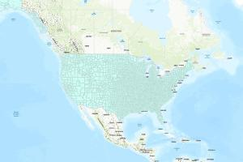

[**demographic_healthexp_clean_allproviders**](https://datascienceqa.esri.com/portal/home/item.html?id=611aca50534d4e3e8700e4ba397ead68)  
Clean Healthcare provider data with demographic and health expenditure information.

[figure not shown]

Feature Layer Collection by portaladmin  
Last Modified: August 17, 2020  
0 comments, 0 views

```python
# Search the feature layer
data_groups = gis.groups.search('"ArcGIS Sample Notebooks Data" owner:esri_notebook',
                                outside_org=True)
group_query = f"group: {data_groups[0].id}" if data_groups else ""
allprovider_item = gis.content.search(f'demographic_healthexp_clean_allproviders {group_query}',
                                      item_type = "Feature Service",
                                      outside_org=True)[0]
allprovider_item
```

```python
# Get the layer
allprovider_layer = allprovider_item.layers[0]
allprovider_layer
```

```
<FeatureLayer url:"https://datascienceqa.esri.com/server/rest/services/Hosted/demographic_healthexp_clean_allproviders/FeatureServer/0">
```

```python
# Look at the first few fields
for f in allprovider_layer.properties.fields[:5]:
    print(f['name'], "{0:>25}".format(f['alias']))
```

```
objectid                  OBJECTID
state                     state
county                    county
asian_pop                 asian_pop
amerind_pop               amerind_pop
```

```python
# Store data from layer as a spatially enabled dataframe
allprovider_df = allprovider_layer.query(as_df=True)
allprovider_df.shape
```

```
(3139, 35)
```

We can see that the dataframe (`allprovider_df`) has 3139 rows and 35 columns.

```python
# Look at the first few rows of dataframe
allprovider_df.head()
```

|  | SHAPE | SHAPE__Area | SHAPE__Length | amerind_pop | asian_pop | asso_deg | avg_healthcare | avg_healthinsurance | avg_hhinc | avg_hhsz | avg_labtest | avg_medicalcare | avg_medicalsrvc | avg_medicare | avg_personalinsurance | avg_presdrug | avg_socsecurity | bach_deg | black_pop | county | edubase | grad_deg | hisp_pop | median_age | minority_pop | objectid | otherace_pop | percap_income | pop_density | … |
| --- | --- | --- | --- | --- | --- | --- | --- | --- | --- | --- | --- | --- | --- | --- | --- | --- | --- | --- | --- | --- | --- | --- | --- | --- | --- | --- | --- | --- | --- | --- |
| 0 | {"rings": [[[-8966174.9526, 4783327.065400004]... | 1.386118e+09 | 181962.662239 | 26 | 33 | 363 | 4466.09 | 2894.59 | 51537 | 2.42 | 52.65 | 1571.51 | 794.24 | 632.30 | 270.40 | 132.74 | 4548.75 | 695 | 201 | Doddridge County | 6405 | 368 | 91 | 43.2 | 467 | 1 | 5 | 20870 | 27.7 | … |
| 1 | {"rings": [[[-9053514.349800002, 4605160.99729... | 2.782337e+09 | 338942.950065 | 112 | 101 | 2901 | 4258.47 | 2763.71 | 50170 | 2.37 | 49.59 | 1494.76 | 759.18 | 592.84 | 257.88 | 124.51 | 4436.31 | 3215 | 2000 | Fayette County | 33677 | 1731 | 540 | 44.7 | 3456 | 2 | 106 | 20953 | 69.2 | … |
| 2 | {"rings": [[[-8986636.588199995, 4735386.19310... | 1.453919e+09 | 190697.949972 | 53 | 51 | 336 | 4182.28 | 2716.19 | 50297 | 2.35 | 47.76 | 1466.09 | 745.24 | 579.07 | 248.70 | 122.37 | 4427.67 | 632 | 1044 | Gilmer County | 6106 | 460 | 479 | 39.0 | 1720 | 3 | 209 | 20296 | 24.5 | … |
| 3 | {"rings": [[[-8792002.250900002, 4755765.97959... | 2.067679e+09 | 253575.180085 | 19 | 26 | 731 | 4382.40 | 2848.84 | 52611 | 2.40 | 50.31 | 1533.57 | 784.03 | 596.32 | 272.29 | 125.52 | 4723.08 | 804 | 118 | Grant County | 9296 | 655 | 171 | 46.9 | 453 | 4 | 82 | 21869 | 26.2 | … |
| 4 | {"rings": [[[-9814179.0036, 5448666.451099999]... | 3.612248e+09 | 304874.767338 | 501 | 1882 | 8678 | 5281.24 | 3469.30 | 72853 | 2.38 | 57.14 | 1811.94 | 974.64 | 594.38 | 357.65 | 124.23 | 6907.69 | 11652 | 1953 | Fond du Lac County | 73127 | 5425 | 5716 | 41.6 | 11180 | 5 | 2234 | 30109 | 144.3 | … |

### Plot Data

Before we plot the data, let's create a copy of `allprovider_df` and drop unnecessary columns.

```python
# Create copy of dataframe
test_newcounty_df = allprovider_df.copy()
```

```python
# Drop the shape and objectid columns
test_newcounty_df.drop(['objectid','SHAPE','SHAPE__Length','SHAPE__Area'], axis=1, inplace=True)
test_newcounty_df.columns
```

```
Index(['amerind_pop', 'asian_pop', 'asso_deg', 'avg_healthcare',
       'avg_healthinsurance', 'avg_hhinc', 'avg_hhsz', 'avg_labtest',
       'avg_medicalcare', 'avg_medicalsrvc', 'avg_medicare',
       'avg_personalinsurance', 'avg_presdrug', 'avg_socsecurity', 'bach_deg',
       'black_pop', 'county', 'edubase', 'grad_deg', 'hisp_pop', 'median_age',
       'minority_pop', 'otherace_pop', 'percap_income', 'pop_density',
       'provider_count', 'some_college', 'state', 'total_population',
       'unemp_rate', 'white_pop'],
      dtype='object')
```

#### Pair Plot

We will plot each numerical variable with respect to others to see how the data is distributed and how correlated the variables are to each other.

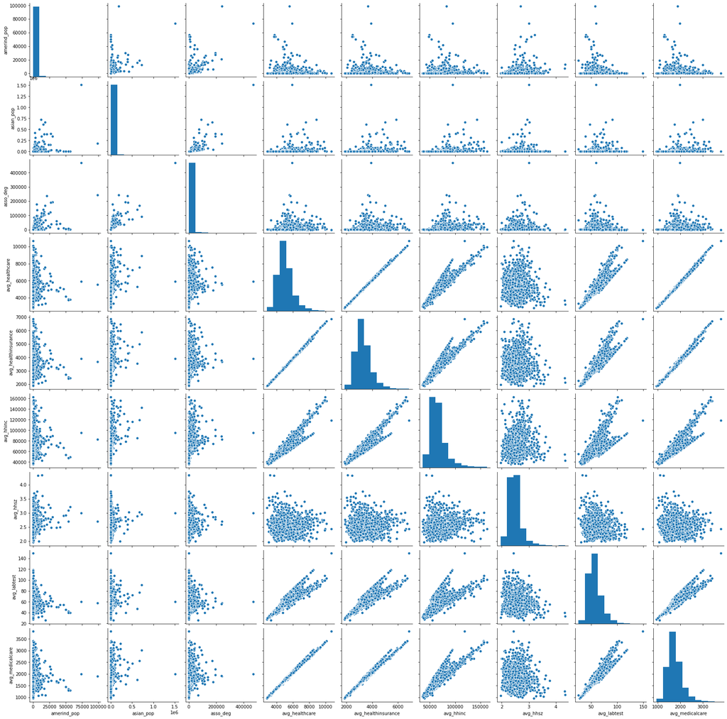

```python
sns.pairplot(test_newcounty_df.iloc[:,0:9]);
```

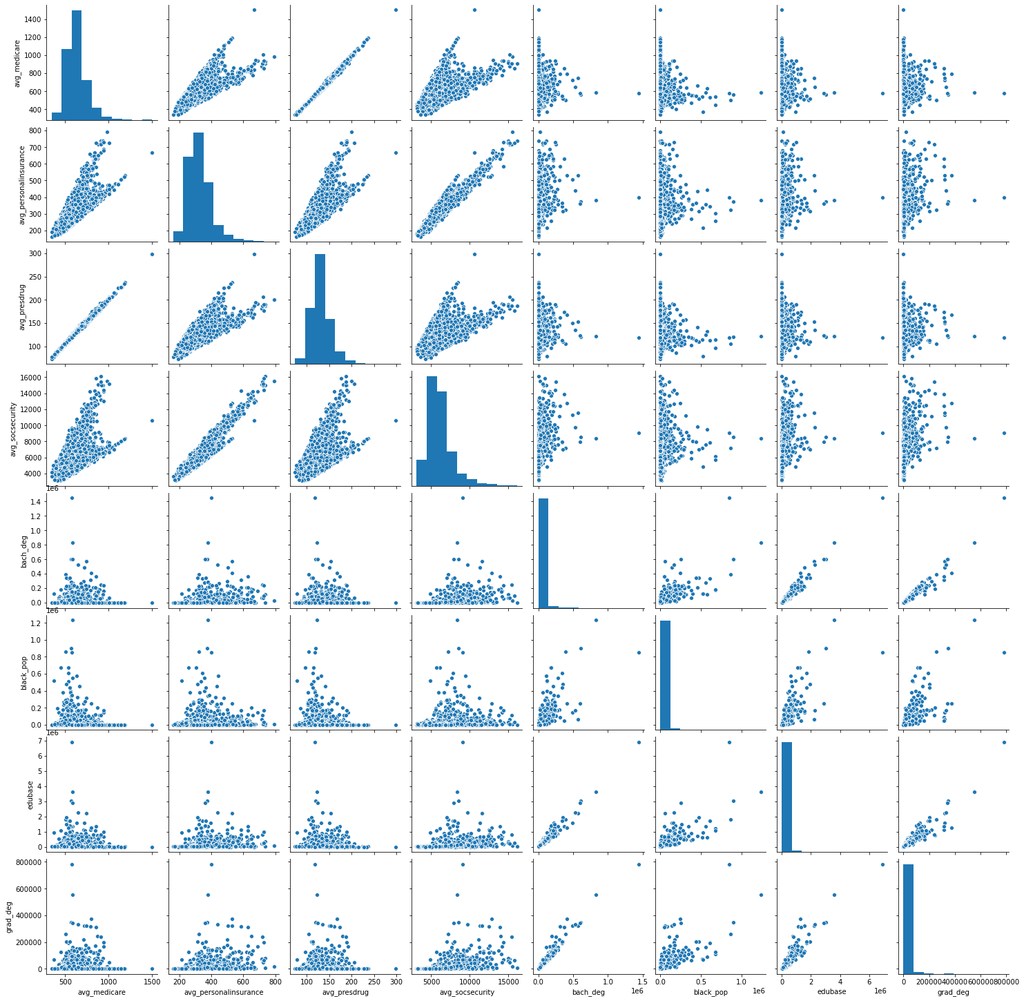

```python
sns.pairplot(test_newcounty_df.iloc[:,10:19]);
```

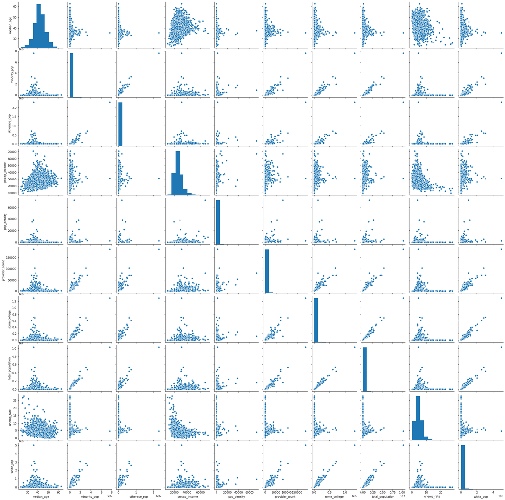

```python
sns.pairplot(test_newcounty_df.iloc[:,20:]);
```

#### Correlation Plot

Correlation plot is another great way to visualize correlation among predictor variables and correlation of predictors with response variable.

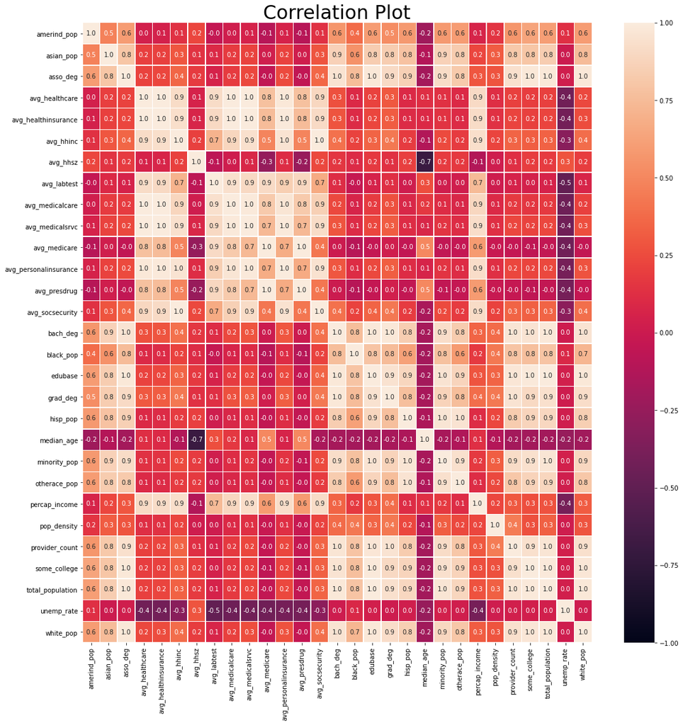

```python
f,ax = plt.subplots(figsize=(18, 18))

sns.heatmap(test_newcounty_df.corr(), vmin=-1.0, vmax=1.0, annot=True,
            linewidths=.5, fmt= '.1f',ax=ax)
plt.title('Correlation Plot', fontdict = {'fontsize' : 30});
```

From this plot, we can see that:

- Education level variables are highly correlated with each other.
- Similarly, health expenditure variables also seem to be highly correlated.

```python
# Sort the values by descending order of Provider Count
test_newcounty_df = test_newcounty_df.sort_values(by=['provider_count'], ascending=False)
test_newcounty_df.head()
```

|  | amerind_pop | asian_pop | asso_deg | avg_healthcare | avg_healthinsurance | avg_hhinc | avg_hhsz | avg_labtest | avg_medicalcare | avg_medicalsrvc | avg_medicare | avg_personalinsurance | avg_presdrug | avg_socsecurity | bach_deg | black_pop | county | edubase | grad_deg | hisp_pop | median_age | minority_pop | otherace_pop | percap_income | pop_density | provider_count | some_college | state | total_population | … |
| --- | --- | --- | --- | --- | --- | --- | --- | --- | --- | --- | --- | --- | --- | --- | --- | --- | --- | --- | --- | --- | --- | --- | --- | --- | --- | --- | --- | --- | --- | --- |
| 1198 | 73559 | 1517296 | 469649 | 5905.52 | 3907.44 | 94861 | 3.00 | 59.76 | 1998.08 | 1132.94 | 579.43 | 399.93 | 118.60 | 9046.16 | 1445895 | 850350 | Los Angeles County | 6899087 | 782758 | 5043293 | 35.7 | 7644196 | 2305030 | 31563 | 2535.5 | 188179.0 | 1300786 | CA | 10288937 | … |
| 2784 | 21113 | 395712 | 237028 | 5692.87 | 3774.06 | 88254 | 2.58 | 56.05 | 1918.81 | 1061.74 | 585.60 | 381.05 | 122.50 | 8356.49 | 830433 | 1233716 | Cook County | 3607345 | 552050 | 1374256 | 36.6 | 3078944 | 608672 | 34083 | 5579.2 | 104037.0 | 690225 | IL | 5274129 | … |
| 2459 | 8756 | 212844 | 48360 | 8035.56 | 5382.10 | 136860 | 2.00 | 69.80 | 2653.46 | 1464.96 | 796.17 | 530.01 | 167.61 | 12793.70 | 406878 | 247085 | New York County | 1251653 | 371255 | 441304 | 37.9 | 899778 | 193191 | 66805 | 72736.2 | 80839.0 | 121070 | NY | 1660472 | … |
| 1614 | 98584 | 184150 | 241714 | 5574.19 | 3675.76 | 83005 | 2.69 | 57.84 | 1898.43 | 1041.69 | 581.95 | 362.02 | 123.67 | 7908.62 | 597653 | 253576 | Maricopa County | 2891837 | 342159 | 1373153 | 35.8 | 1981147 | 598035 | 30701 | 476.9 | 71069.0 | 711033 | AZ | 4387226 | … |
| 1405 | 30001 | 341640 | 193511 | 5800.32 | 3840.81 | 89252 | 2.85 | 60.64 | 1959.50 | 1087.37 | 564.48 | 374.86 | 119.69 | 8547.08 | 605813 | 901459 | Harris County | 3029538 | 345886 | 2035551 | 33.5 | 3339578 | 712410 | 31405 | 2780.1 | 70953.0 | 606842 | TX | 4735852 | … |

## Generate a Global Model

The idea behind a global model is to identify various socioeconomic and demographic factors that influence access to healthcare providers across all counties in the United States.

To build this global model, we will follow a 3 step process:

```
1. Build an Ordinary Least Squares (OLS) Regression Model and verify regressions assumptions
2. Perform Feature Selection using Lasso, Elastic Net and Recursive Feature Elimination techniques
3. Using selected features, build another OLS model, check performance and verify assumptions
```

### Create Predictor and Response Variables

```python
# Create predictor variables
train_pred = test_newcounty_df.drop(['county','state','provider_count'],axis=1)
train_pred.head()
```

|  | amerind_pop | asian_pop | asso_deg | avg_healthcare | avg_healthinsurance | avg_hhinc | avg_hhsz | avg_labtest | avg_medicalcare | avg_medicalsrvc | avg_medicare | avg_personalinsurance | avg_presdrug | avg_socsecurity | bach_deg | black_pop | edubase | grad_deg | hisp_pop | median_age | minority_pop | otherace_pop | percap_income | pop_density | some_college | total_population | unemp_rate | white_pop |
| --- | --- | --- | --- | --- | --- | --- | --- | --- | --- | --- | --- | --- | --- | --- | --- | --- | --- | --- | --- | --- | --- | --- | --- | --- | --- | --- | --- | --- |
| 1198 | 73559 | 1517296 | 469649 | 5905.52 | 3907.44 | 94861 | 3.00 | 59.76 | 1998.08 | 1132.94 | 579.43 | 399.93 | 118.60 | 9046.16 | 1445895 | 850350 | 6899087 | 782758 | 5043293 | 35.7 | 7644196 | 2305030 | 31563 | 2535.5 | 1300786 | 10288937 | 4.5 | 5019340 |
| 2784 | 21113 | 395712 | 237028 | 5692.87 | 3774.06 | 88254 | 2.58 | 56.05 | 1918.81 | 1061.74 | 585.60 | 381.05 | 122.50 | 8356.49 | 830433 | 1233716 | 3607345 | 552050 | 1374256 | 36.6 | 3078944 | 608672 | 34083 | 5579.2 | 690225 | 5274129 | 6.9 | 2859209 |
| 2459 | 8756 | 212844 | 48360 | 8035.56 | 5382.10 | 136860 | 2.00 | 69.80 | 2653.46 | 1464.96 | 796.17 | 530.01 | 167.61 | 12793.70 | 406878 | 247085 | 1251653 | 371255 | 441304 | 37.9 | 899778 | 193191 | 66805 | 72736.2 | 121070 | 1660472 | 3.9 | 924396 |
| 1614 | 98584 | 184150 | 241714 | 5574.19 | 3675.76 | 83005 | 2.69 | 57.84 | 1898.43 | 1041.69 | 581.95 | 362.02 | 123.67 | 7908.62 | 597653 | 253576 | 2891837 | 342159 | 1373153 | 35.8 | 1981147 | 598035 | 30701 | 476.9 | 711033 | 4387226 | 5.3 | 3066684 |
| 1405 | 30001 | 341640 | 193511 | 5800.32 | 3840.81 | 89252 | 2.85 | 60.64 | 1959.50 | 1087.37 | 564.48 | 374.86 | 119.69 | 8547.08 | 605813 | 901459 | 3029538 | 345886 | 2035551 | 33.5 | 3339578 | 712410 | 31405 | 2780.1 | 606842 | 4735852 | 5.9 | 2573473 |

```python
# Create response variables
train_y = test_newcounty_df['provider_count']
train_y.head()
```

```
1198    188179.0
2784    104037.0
2459     80839.0
1614     71069.0
1405     70953.0
Name: provider_count, dtype: float64
```

### Create a Base Model

We will start with building an Ordinary Least Squares (OLS) Regression [[1]](https://en.wikipedia.org/wiki/Ordinary_least_squares) model with all predictors and verify regressions assumptions.

```python
# Import libraries
import statsmodels.api as sm
# import statsmodels
from statsmodels.regression import linear_model

# Set the seed for consistent results
np.random.seed(101)
```

#### Linear Regression Model using Stats Models

```python
# Create Model
X_train = train_pred
X_train = sm.add_constant(X_train) # add constant
sm_ols = sm.OLS(train_y, X_train).fit()
```

```python
# Generate model summary
sm_ols.summary()
```

OLS Regression Results

| Dep. Variable: | provider_count | R-squared: | 0.972 |
| --- | --- | --- | --- |
| Model: | OLS | Adj. R-squared: | 0.972 |
| Method: | Least Squares | F-statistic: | 3863. |
| Date: | Mon, 17 Aug 2020 | Prob (F-statistic): | 0.00 |
| Time: | 14:21:29 | Log-Likelihood: | -26469. |
| No. Observations: | 3139 | AIC: | 5.300e+04 |
| Df Residuals: | 3110 | BIC: | 5.317e+04 |
| Df Model: | 28 |  |  |
| Covariance Type: | nonrobust |  |  |

|  | coef | std err | t | P>\|t\| | [0.025 | 0.975] |
| --- | --- | --- | --- | --- | --- | --- |
| const | 2632.0977 | 840.995 | 3.130 | 0.002 | 983.137 | 4281.059 |
| amerind_pop | -0.0445 | 0.009 | -5.236 | 0.000 | -0.061 | -0.028 |
| asian_pop | -0.0838 | 0.006 | -14.154 | 0.000 | -0.095 | -0.072 |
| asso_deg | 0.0251 | 0.011 | 2.259 | 0.024 | 0.003 | 0.047 |
| avg_healthcare | 468.7517 | 3996.627 | 0.117 | 0.907 | -7367.543 | 8305.047 |
| avg_healthinsurance | -463.0344 | 3996.586 | -0.116 | 0.908 | -8299.249 | 7373.180 |
| avg_hhinc | 0.2111 | 0.128 | 1.647 | 0.100 | -0.040 | 0.462 |
| avg_hhsz | -134.0568 | 252.876 | -0.530 | 0.596 | -629.878 | 361.765 |
| avg_labtest | -106.1273 | 52.970 | -2.004 | 0.045 | -209.987 | -2.267 |
| avg_medicalcare | -460.9320 | 3997.058 | -0.115 | 0.908 | -8298.073 | 7376.209 |
| avg_medicalsrvc | -1.7558 | 14.157 | -0.124 | 0.901 | -29.513 | 26.002 |
| avg_medicare | 4.8259 | 12.003 | 0.402 | 0.688 | -18.709 | 28.361 |
| avg_personalinsurance | 3.0744 | 8.394 | 0.366 | 0.714 | -13.385 | 19.534 |
| avg_presdrug | -133.4695 | 64.206 | -2.079 | 0.038 | -259.360 | -7.579 |
| avg_socsecurity | -4.7149 | 1.430 | -3.297 | 0.001 | -7.519 | -1.911 |
| bach_deg | -0.0004 | 0.004 | -0.091 | 0.928 | -0.009 | 0.008 |
| black_pop | -0.0576 | 0.005 | -12.104 | 0.000 | -0.067 | -0.048 |
| edubase | 0.0574 | 0.004 | 16.112 | 0.000 | 0.050 | 0.064 |
| grad_deg | 0.0798 | 0.005 | 17.414 | 0.000 | 0.071 | 0.089 |
| hisp_pop | -0.0880 | 0.012 | -7.570 | 0.000 | -0.111 | -0.065 |
| median_age | -52.1251 | 10.225 | -5.098 | 0.000 | -72.174 | -32.076 |
| minority_pop | 0.0954 | 0.012 | 7.895 | 0.000 | 0.072 | 0.119 |
| otherace_pop | 0.0370 | 0.011 | 3.304 | 0.001 | 0.015 | 0.059 |
| percap_income | 0.1126 | 0.025 | 4.544 | 0.000 | 0.064 | 0.161 |
| pop_density | 0.3258 | 0.022 | 15.136 | 0.000 | 0.284 | 0.368 |
| some_college | -0.0116 | 0.005 | -2.309 | 0.021 | -0.021 | -0.002 |
| total_population | -0.0610 | 0.010 | -5.978 | 0.000 | -0.081 | -0.041 |
| unemp_rate | -1.7981 | 9.948 | -0.181 | 0.857 | -21.304 | 17.707 |
| white_pop | 0.0323 | 0.010 | 3.168 | 0.002 | 0.012 | 0.052 |

| Omnibus: | 1740.052 | Durbin-Watson: | 1.824 |
| --- | --- | --- | --- |
| Prob(Omnibus): | 0.000 | Jarque-Bera (JB): | 397367.718 |
| Skew: | 1.487 | Prob(JB): | 0.00 |
| Kurtosis: | 58.039 | Cond. No. | 1.88e+08 |

Warnings:  
[1] Standard Errors assume that the covariance matrix of the errors is correctly specified.  
[2] The condition number is large, 1.88e+08. This might indicate that there are  
strong multicollinearity or other numerical problems.

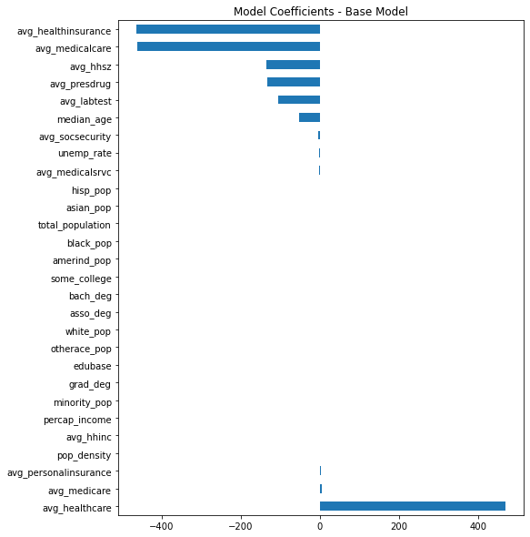

```python
# Plot coefficients picked by model along with their importance
import matplotlib
matplotlib.rcParams['figure.figsize'] = (8.0, 10.0)
sm_ols.params[1:].sort_values(ascending=False).plot(kind='barh')
plt.title('Model Coefficients - Base Model');
```

```python
# Calculate RMSE of model
from statsmodels.tools.eval_measures import rmse

pred_val = sm_ols.fittedvalues.copy()
rmse_base_ols = rmse(train_y, pred_val)

print('RMSE for Base Model:',round(rmse_base_ols,2))
```

```
RMSE for Base Model: 1111.25
```

> Analysing the model summary, we can see that:
> - The R-squared value of 0.972 shows that 97.2% of the variability in Provider Count is explained by the model. The R-squared value is too good to be true and the model seems to be overfitting.
> - To identify variables that are statistically significant, we look at the p-values of individual variables. Among the coefficients, those that are statistically significant at 90% significance level are:
> - asian_pop, amerind_pop, black_pop, edubase, hisp_pop, median_age, minority_pop, otherace_pop, percap_income, pop_density, white_pop, some_college, asso_deg, grad_deg, total_population, avg_labtest, avg_presdrug, avg_socsecurity.
> - The p-value of F-statistic is less than 0.05 which shows that atleast one of the predicting variables has predicting power on the variability of Provider Count.

#### Verify Assumptions

Here, we will verify regression assumtions [[2]](https://online.stat.psu.edu/stat501/lesson/7/7.3) of:

- Linearity
- Independence
- Normality
- Equal Variance

```python
# Get residual value
residual = sm_ols.resid
```

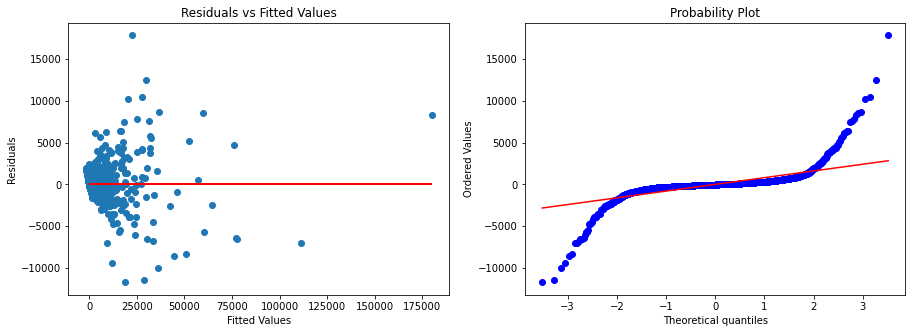

```python
import scipy as sp
fig, (ax1, ax2) = plt.subplots(1,2,figsize=(15,5))

# Residuals vs Fitted
ax1.scatter(pred_val, residual)
ax1.hlines(y=0, xmin=0, xmax=max(pred_val), linewidth=2, color='r')
ax1.set_xlabel('Fitted Values')
ax1.set_ylabel('Residuals')
ax1.set_title('Residuals vs Fitted Values')

# QQ plot
sp.stats.probplot(residual, plot=ax2, fit=True);
```

1. Residuals vs Fitted plot
   - **Constant Variance**: From the plot, we observe a departure from constant variance as the distance of data points from zero are not consistently equal. We can see that the residuals are closer to 0 in the beginning but values start to go up as we move a little towards the right of the plot.
   - **Independence**: We see that the data is clustered together and is not randomly distributed. This indicates a departure from independence as clusters of residuals generally indicate correlation errors, or an indication that multicollinearity exists in parts of the data.
1. Probability Plot
   - **Normality**: From this plot, we can see that the residuals have tails on both the positive and negative side. Although residuals stay close to the zero line they are heavily tailed showing violation of Normality assumption.

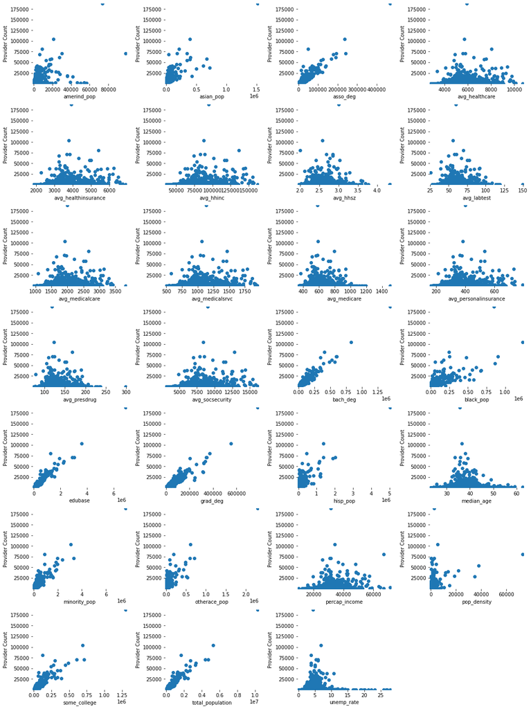

```python
# Check Linearity - Plot predictors with response
preds = train_pred.columns
fig = plt.figure(figsize=(15, 20))
for sp in range(0,27):
    ax = fig.add_subplot(7,4,sp+1)
    ax.scatter(train_pred.loc[:,preds[sp]], train_y)
    ax.set_xlabel(preds[sp])
    ax.set_ylabel('Provider Count')
    plt.xticks(rotation=0)
    for key, spine in ax.spines.items():
        spine.set_visible(False)
    ax.margins(0.01, 0)
plt.tight_layout(pad=1.0) # automatically adjusts layout to fit long labels
plt.show()
```

1. Predictors vs Response
   - **Linearity** - From the plot above, we can see the each predictor variable is either strongly or weakly related to response variable. From this plot, we can say that the Linearity assumption holds.

#### Outlier Detection

One way to think about whether the results we have are driven by a given data point is to calculate how far the predicted values for data would move if model was fit without the data point in question. This calculated total distance is called Cook's distance. Cook's D is a function of the leverage and standardized residual associated with each data point. The influence of each point can be visualized using an Influence Plot [[3]](https://sites.google.com/site/statisticsforspreadsheets/regression-modeling/influence-plot).

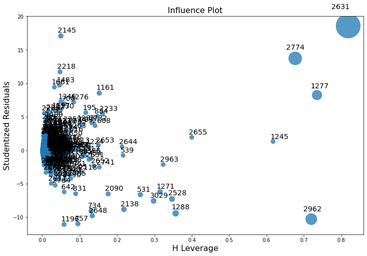

```python
# Create Influence Plot

fig, ax = plt.subplots(figsize=(12,8))
fig = sm.graphics.influence_plot(sm_ols, ax= ax, criterion="cooks")
```

From this plot, we can see that points with larger size have high leverage and higher than average residuals. The larger size of points indicates these are influential points. Points that do not have a high leverage but very high residual and are considered outliers.

Note that numbers shown next to the points in this plot are observation numbers (row ids) from the data. This context is important to understand the following section for removing outliers.

#### Remove Outliers

Removing outliers is an iterative process and outliers need to be investigated before removal. Here, we followed a 4-step process to remove outliers as follows:

1. Remove initial outliers based on Influence Plot
2. Rerun the model with data after removing outliers
3. Plot predictors with response to see outliers in each predictor
4. Repeat the process above until you see satisfactory results

The outliers were removed in different iterations. Here are the obervations that were removed with each iteration:

```
- Iteration 1: 2631,2774,1277,1245,296
- Iteration 2: 1198,2353,2459,1688,1077
- Iteration 3: 916,2632,2262,1207,797,531
- Iteration 4: 2613,310,1052,38,1632,1512
- Iteration 5: 629,1846,2710,388,1614,2784,1727
```

The code below shows all outliers being removed. If you see a different set of points as outliers for your analysis, update the `global_df.drop()` command in code cell below with outlier observations and run the analysis.

```python
# Remove Outliers
global_df = test_newcounty_df.copy()

global_df.drop([2631,2774,1277,1245,296,
                1198,2353,2459,1688,1077,
                916,2632,2262,1207,797,531,
                2613, 310, 1052, 38, 1632, 1512,
                629, 1846, 2710, 388, 1614, 2784, 1727],axis=0, inplace=True)
```

```python
global_df.shape
```

```
(3110, 31)
```

##### Re-run Model

```python
# Create prdictor and response variables
train_x_rerun = global_df.drop(['county','state','provider_count'],axis=1)
train_y_rerun = global_df['provider_count']
train_x_rerun.head()
```

|  | amerind_pop | asian_pop | asso_deg | avg_healthcare | avg_healthinsurance | avg_hhinc | avg_hhsz | avg_labtest | avg_medicalcare | avg_medicalsrvc | avg_medicare | avg_personalinsurance | avg_presdrug | avg_socsecurity | bach_deg | black_pop | edubase | grad_deg | hisp_pop | median_age | minority_pop | otherace_pop | percap_income | pop_density | some_college | total_population | unemp_rate | white_pop |
| --- | --- | --- | --- | --- | --- | --- | --- | --- | --- | --- | --- | --- | --- | --- | --- | --- | --- | --- | --- | --- | --- | --- | --- | --- | --- | --- | --- | --- |
| 1405 | 30001 | 341640 | 193511 | 5800.32 | 3840.81 | 89252 | 2.85 | 60.64 | 1959.50 | 1087.37 | 564.48 | 374.86 | 119.69 | 8547.08 | 605813 | 901459 | 3029538 | 345886 | 2035551 | 33.5 | 3339578 | 712410 | 31405 | 2780.1 | 606842 | 4735852 | 5.9 | 2573473 |
| 1698 | 27438 | 401095 | 191669 | 6514.21 | 4306.51 | 101373 | 2.77 | 66.80 | 2207.70 | 1234.01 | 649.22 | 439.85 | 135.09 | 9730.65 | 525473 | 168807 | 2246969 | 331783 | 1144104 | 35.7 | 1844110 | 483908 | 36291 | 795.0 | 487496 | 3344185 | 3.9 | 2056884 |
| 1348 | 17234 | 395459 | 126421 | 7408.65 | 4907.57 | 117025 | 2.42 | 74.96 | 2501.08 | 1398.15 | 720.68 | 505.47 | 150.11 | 11292.96 | 484710 | 146077 | 1552376 | 320833 | 216100 | 38.3 | 891019 | 94894 | 47839 | 1039.6 | 278602 | 2199247 | 5.0 | 1401488 |
| 209 | 17668 | 170268 | 102480 | 5366.30 | 3553.67 | 82550 | 2.76 | 55.22 | 1812.63 | 1000.06 | 534.73 | 342.48 | 113.62 | 7832.26 | 337376 | 608225 | 1709385 | 193333 | 1072941 | 33.6 | 1890363 | 436469 | 29987 | 3046.4 | 332724 | 2654282 | 4.8 | 1335362 |
| 1355 | 6003 | 70007 | 138229 | 5441.04 | 3587.55 | 80411 | 2.56 | 55.26 | 1853.49 | 1012.03 | 585.04 | 357.09 | 124.13 | 7615.72 | 279433 | 555082 | 1358758 | 159309 | 574151 | 41.0 | 1224672 | 83078 | 31438 | 1571.7 | 263467 | 1901425 | 5.3 | 1120747 |

```python
# Run Model
X_train_rerun = train_x_rerun
X_train_rerun = sm.add_constant(X_train_rerun)
global_ols_rerun = sm.OLS(train_y_rerun, X_train_rerun).fit()
residual = global_ols_rerun.resid
```

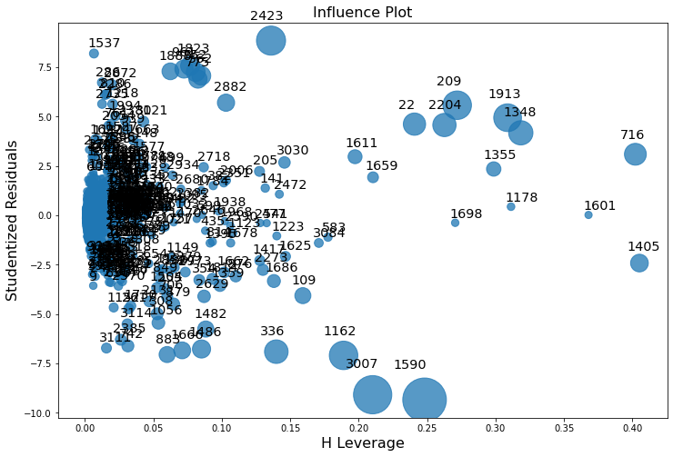

```python
# Plot Outliers
fig, ax = plt.subplots(figsize=(12,8))
fig = sm.graphics.influence_plot(global_ols_rerun, ax= ax, criterion="cooks")
```

Comparing this influece plot to the original plot before removing outliers, we can see that the range for `H Leverage` has considerably reduced from `0.0 - 0.8 to 0.0 - 0.40`. The range for `Studentized Residuals` has also reduced from `-12.0 - 20.0 to -10.0 - 10.0`.

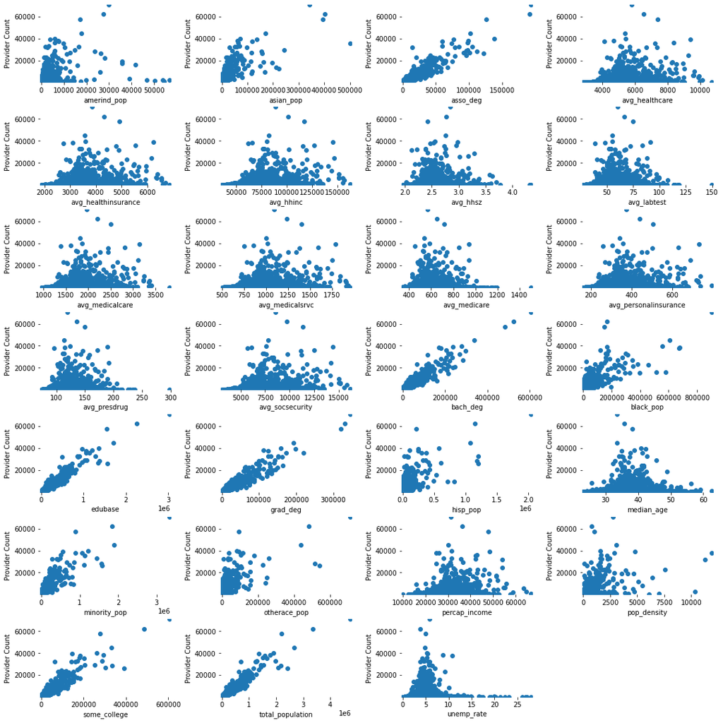

```python
# Check Linearity - Plot predictors with response
preds = train_x_rerun.columns
fig = plt.figure(figsize=(15, 15))
for sp in range(0,27):
    ax = fig.add_subplot(7,4,sp+1)
    ax.scatter(train_x_rerun.loc[:,preds[sp]], train_y_rerun)
    ax.set_xlabel(preds[sp])
    ax.set_ylabel('Provider Count')
    plt.xticks(rotation=0)
    for key, spine in ax.spines.items():
        spine.set_visible(False)
    ax.margins(0.01, 0)
plt.tight_layout(pad=0.5) # automatically adjusts layout to fit long labels
plt.show()
```

### Feature Selection and Importance

Greedy algorithms like `Stepwise Regression` [[4]](https://online.stat.psu.edu/stat501/lesson/10/10.2) and `Recursive Feature Elimination (RFE)` [[5]](https://bookdown.org/max/FES/recursive-feature-elimination.html) work by adding or removing attributes one at a time and building a model on those attributes that remain. RFE algorithm recursively removes attributes and uses accuracy metric to rank the feature according to their importance.

Regularization methods like `Lasso` [[6]](https://towardsdatascience.com/ridge-lasso-and-elastic-net-regularization-7861ca575c64) and `ElasticNet` [[6]](https://towardsdatascience.com/ridge-lasso-and-elastic-net-regularization-7861ca575c64) seek to minimize the complexity (magnitude and number of regression coefficients) of the model by penalizing a feature given a coefficient threshold.

- Lasso penalizes the sum of absolute value of regression coefficients thereby forcing many coefficients to 0.
- ElasticNet combines the properties of both Lasso (L1 term) and Ridge [[6]](https://towardsdatascience.com/ridge-lasso-and-elastic-net-regularization-7861ca575c64) (L2 term) regression. It penalizes the model by using both the L2-norm (sum of squared values of coefficients) and the L1-norm (sum of absolute value of coefficients) thereby shrinking some coefficients closer to 0 to reduce variance and making other coefficients 0.

Feature importance techniques like `Random Forest` [[7]](https://towardsdatascience.com/feature-selection-using-random-forest-26d7b747597f) are used to select features using a trained supervised classifier. Random forest consists of a number of decision trees where each node in a tree is a condition on a single feature, designed to split the dataset.

Here we will:

- Run some feature selection algorithms
- Choose an algorithm with lowest error
- Run the chosen algorithm on all predictors
- Choose the predictors selected by this model for further analysis

```python
# Create prdictor and response variables
train_x_global = train_x_rerun
train_y_global = train_y_rerun
train_x_global.head()
```

|  | amerind_pop | asian_pop | asso_deg | avg_healthcare | avg_healthinsurance | avg_hhinc | avg_hhsz | avg_labtest | avg_medicalcare | avg_medicalsrvc | avg_medicare | avg_personalinsurance | avg_presdrug | avg_socsecurity | bach_deg | black_pop | edubase | grad_deg | hisp_pop | median_age | minority_pop | otherace_pop | percap_income | pop_density | some_college | total_population | unemp_rate | white_pop |
| --- | --- | --- | --- | --- | --- | --- | --- | --- | --- | --- | --- | --- | --- | --- | --- | --- | --- | --- | --- | --- | --- | --- | --- | --- | --- | --- | --- | --- |
| 1405 | 30001 | 341640 | 193511 | 5800.32 | 3840.81 | 89252 | 2.85 | 60.64 | 1959.50 | 1087.37 | 564.48 | 374.86 | 119.69 | 8547.08 | 605813 | 901459 | 3029538 | 345886 | 2035551 | 33.5 | 3339578 | 712410 | 31405 | 2780.1 | 606842 | 4735852 | 5.9 | 2573473 |
| 1698 | 27438 | 401095 | 191669 | 6514.21 | 4306.51 | 101373 | 2.77 | 66.80 | 2207.70 | 1234.01 | 649.22 | 439.85 | 135.09 | 9730.65 | 525473 | 168807 | 2246969 | 331783 | 1144104 | 35.7 | 1844110 | 483908 | 36291 | 795.0 | 487496 | 3344185 | 3.9 | 2056884 |
| 1348 | 17234 | 395459 | 126421 | 7408.65 | 4907.57 | 117025 | 2.42 | 74.96 | 2501.08 | 1398.15 | 720.68 | 505.47 | 150.11 | 11292.96 | 484710 | 146077 | 1552376 | 320833 | 216100 | 38.3 | 891019 | 94894 | 47839 | 1039.6 | 278602 | 2199247 | 5.0 | 1401488 |
| 209 | 17668 | 170268 | 102480 | 5366.30 | 3553.67 | 82550 | 2.76 | 55.22 | 1812.63 | 1000.06 | 534.73 | 342.48 | 113.62 | 7832.26 | 337376 | 608225 | 1709385 | 193333 | 1072941 | 33.6 | 1890363 | 436469 | 29987 | 3046.4 | 332724 | 2654282 | 4.8 | 1335362 |
| 1355 | 6003 | 70007 | 138229 | 5441.04 | 3587.55 | 80411 | 2.56 | 55.26 | 1853.49 | 1012.03 | 585.04 | 357.09 | 124.13 | 7615.72 | 279433 | 555082 | 1358758 | 159309 | 574151 | 41.0 | 1224672 | 83078 | 31438 | 1571.7 | 263467 | 1901425 | 5.3 | 1120747 |

```python
# Import Libraries
from sklearn.preprocessing import StandardScaler
from sklearn.model_selection import KFold
from sklearn.model_selection import cross_val_score
from sklearn.linear_model import Lasso
from sklearn.linear_model import ElasticNet
from sklearn.pipeline import Pipeline
from sklearn.metrics import mean_squared_error
from sklearn.ensemble import RandomForestRegressor
from sklearn.feature_selection import RFECV
from sklearn.linear_model import LinearRegression
```

#### Run Feature Selection Algorithms

```python
# Test options and evaluation metric
num_folds = 10
seed = 7
scoring ='neg_mean_squared_error'
```

```python
# Create Pipeline and Standardize the dataset
clf = LinearRegression()
pipelines = []
pipelines.append(('ScaledLASSO', Pipeline([('Scaler', StandardScaler()),('LASSO',Lasso(max_iter=10000))])))
pipelines.append(('ScaledEN', Pipeline([('Scaler', StandardScaler()),('EN',ElasticNet())])))
pipelines.append(('ScaledRFECV', Pipeline([('Scaler', StandardScaler()),('RFECV',RFECV(estimator=clf, cv=5))])))
pipelines.append(('ScaledRF', Pipeline([('Scaler', StandardScaler()),('RF',RandomForestRegressor(n_estimators = 100))])))
```

```python
# Run models
import math
results = []
names = []
for name, model in pipelines:
    kfold = KFold(n_splits=num_folds, random_state=seed,shuffle=True)
    cv_results = cross_val_score(model, train_x_global, train_y_global, cv=kfold, scoring=scoring)
    results.append(cv_results)
    names.append(name)
    msg = "%s: %f (%f)" % (name, math.sqrt(abs(cv_results.mean())), cv_results.std())
    print(msg)
```

```
ScaledLASSO: 810.966882 (144215.366577)
ScaledEN: 1036.948941 (257837.375171)
ScaledRFECV: 823.745259 (121412.751591)
ScaledRF: 1069.088212 (951602.468757)
```

From the results above, Lasso seems to be the most promising with lowest RMSE. Let's explore Lasso to see which variables are selected by this model.

#### Identify Features Using Lasso

```python
# Standardize the data using Standard Scalar
from sklearn.preprocessing import StandardScaler
train_x_std = StandardScaler().fit_transform(train_x_global)
```

```python
# Run Lasso Model
from sklearn.linear_model import Lasso
# from sklearn.linear_model import ElasticNet
lasso_model=Lasso(max_iter=10000)
lasso_model.fit(train_x_std,train_y_global)
```

```
Lasso(max_iter=10000)
```

```python
# Identify how many variables are picked
coef = pd.Series(lasso_model.coef_, index = train_pred.columns)
print("Model picked " + str(sum(coef != 0)) + " variables and eliminated the other " +  str(sum(coef == 0)) + " variables")
```

```
Model picked 20 variables and eliminated the other 8 variables
```

```python
# Get important variables and their coefficients
imp_coef = pd.concat([coef.sort_values(ascending=False).head(10),
                     coef.sort_values(ascending=False).tail(10)])
imp_coef
```

```
minority_pop        6112.644751
grad_deg            3080.902796
total_population    1746.411139
edubase             1045.670237
percap_income        651.533545
asso_deg             632.276396
avg_medicare         612.894279
pop_density          161.600102
avg_hhsz              49.771492
white_pop             -0.000000
unemp_rate           -53.553069
median_age          -180.673223
otherace_pop        -189.915878
some_college        -399.935748
avg_presdrug        -574.941967
avg_socsecurity     -951.248207
asian_pop          -1269.292044
bach_deg           -1703.537961
black_pop          -1950.128199
hisp_pop           -3752.211812
dtype: float64
```

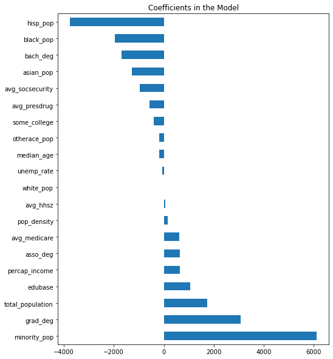

```python
# Plot coefficients picked by model along with their importance
import matplotlib
matplotlib.rcParams['figure.figsize'] = (8.0, 10.0)
imp_coef.plot(kind = "barh")
plt.title("Coefficients in the Model");
```

From the analysis above, we can see that factors that are predictive of higher provider count are:

- minority_pop (2020 Minority Population (Esri))
- grad_deg (2020 Education: Graduate/Professional Degree (Esri))
- total_population (2020 Total Population (Esri))
- percap_income (2020 Per Capita Income (Esri))
- avg_medicare (2020 Medicare Payments: Average)
- asso_deg (2020 Education: Associate's Degree (Esri))
- edubase (2020 Educational Attainment Base (Esri))
- pop_density (2020 Population Density (Pop per Square Mile) (Esri))
- avg_hhsz (2020 Average Household Size (Esri))

Factors that negatively influence provider count are:

- hisp_pop (2020 Hispanic Population (Esri))
- black_pop (2020 Black/African American Population (Esri))
- bach_deg (2020 Education: Bachelor's Degree (Esri))
- asian_pop (2020 Asian Population (Esri))
- avg_socsecurity (2020 Pensions & Social Security: Average)
- avg_presdrug (2020 Prescription Drugs: Average)
- median_age (2020 Median Age (Esri))
- some_college (2020 Education: Some College/No Degree (Esri))
- otherrace_pop (2020 Other Race Population by Age Base (Esri))
- unemp_rate (2020 Unemployment Rate (Esri))

### Regression with Selected Features

**For Linearity** - If a model does not fit well, it does not mean that the regression is not useful. One problem could be that the relation between one or more predictors and the response is not linear.

**For Constant Variance and Independence** - If normality or the constant variance do not hold, then we transform the response variable. A common transformation is the power transformation of y to the lambda.

Here we will use the features selected by lasso model, and `transform` both the predictor and response variables to create a regression model on our data.

#### Clean the Data

Some transformations such as `Log transformation` [[8]](https://www.ncbi.nlm.nih.gov/pmc/articles/PMC4120293/) do not work well with zero or negative values. We do not have any negatives but let's check and remove any zero values from the data.

```python
# Create a copy of dataframe
test_log = global_df.copy()
test_log.shape
```

```
(3110, 31)
```

```python
# Describe to identify any zero values in dataset
test_log.describe().transpose()
```

|  | count | mean | std | min | 25% | 50% | 75% | max |
| --- | --- | --- | --- | --- | --- | --- | --- | --- |
| amerind_pop | 3110.0 | 925.189389 | 3253.585408 | 0.00 | 61.0000 | 160.000 | 523.5000 | 56871.00 |
| asian_pop | 3110.0 | 3841.547267 | 20680.860712 | 0.00 | 48.0000 | 162.000 | 803.7500 | 501246.00 |
| asso_deg | 3110.0 | 5340.767524 | 12191.720275 | 5.00 | 647.2500 | 1596.500 | 4428.7500 | 193511.00 |
| avg_healthcare | 3110.0 | 5078.543723 | 947.949453 | 2821.51 | 4437.6100 | 4927.990 | 5558.7475 | 10690.41 |
| avg_healthinsurance | 3110.0 | 3318.752814 | 625.270951 | 1871.50 | 2899.4575 | 3221.570 | 3633.6175 | 6873.42 |
| avg_hhinc | 3110.0 | 66116.593891 | 15742.065759 | 36078.00 | 55847.7500 | 63405.500 | 72196.2500 | 162801.00 |
| avg_hhsz | 3110.0 | 2.484016 | 0.218515 | 1.96 | 2.3500 | 2.460 | 2.5700 | 4.34 |
| avg_labtest | 3110.0 | 57.226193 | 12.376326 | 27.75 | 49.0125 | 54.795 | 63.1475 | 149.41 |
| avg_medicalcare | 3110.0 | 1759.790894 | 324.316111 | 950.01 | 1541.2025 | 1705.395 | 1921.3075 | 3816.99 |
| avg_medicalsrvc | 3110.0 | 926.770312 | 186.200670 | 496.89 | 799.9600 | 897.325 | 1020.8125 | 1955.37 |
| avg_medicare | 3110.0 | 628.224878 | 110.561226 | 342.05 | 556.8850 | 610.050 | 682.0225 | 1501.33 |
| avg_personalinsurance | 3110.0 | 326.753232 | 74.904571 | 162.69 | 276.3250 | 315.235 | 362.0075 | 791.45 |
| avg_presdrug | 3110.0 | 131.243627 | 21.053413 | 73.65 | 117.8525 | 128.335 | 141.7175 | 298.34 |
| avg_socsecurity | 3110.0 | 6112.216814 | 1642.662502 | 3121.71 | 5053.2750 | 5813.570 | 6727.9125 | 16133.33 |
| bach_deg | 3110.0 | 11675.685209 | 33447.991357 | 2.00 | 846.0000 | 2118.000 | 6539.2500 | 605813.00 |
| black_pop | 3110.0 | 11506.624759 | 44758.931850 | 0.00 | 121.0000 | 840.000 | 5567.5000 | 901459.00 |
| edubase | 3110.0 | 61346.768489 | 149479.894659 | 69.00 | 7912.5000 | 18437.500 | 46770.7500 | 3029538.00 |
| grad_deg | 3110.0 | 7112.766881 | 21273.455845 | 0.00 | 420.2500 | 1141.500 | 3759.2500 | 345886.00 |
| hisp_pop | 3110.0 | 14253.300322 | 73794.908292 | 0.00 | 378.0000 | 1128.000 | 5182.7500 | 2035551.00 |
| median_age | 3110.0 | 41.960514 | 5.362405 | 23.20 | 38.7250 | 41.900 | 45.2000 | 62.50 |
| minority_pop | 3110.0 | 32202.119614 | 125773.042120 | 4.00 | 1270.2500 | 4461.000 | 15167.5000 | 3339578.00 |
| otherace_pop | 3110.0 | 5257.274920 | 27156.607632 | 0.00 | 109.0000 | 422.000 | 1985.7500 | 712410.00 |
| percap_income | 3110.0 | 26343.677170 | 6071.379975 | 9853.00 | 22218.2500 | 25470.500 | 29272.2500 | 66766.00 |
| pop_density | 3110.0 | 193.653055 | 611.577761 | 0.00 | 17.1000 | 45.600 | 114.7000 | 11869.90 |
| provider_count | 3110.0 | 1498.314469 | 4319.913817 | 1.00 | 88.0000 | 263.000 | 935.7500 | 70953.00 |
| some_college | 3110.0 | 12867.820257 | 30879.598848 | 22.00 | 1666.2500 | 3847.000 | 10220.7500 | 606842.00 |
| total_population | 3110.0 | 90102.121543 | 223536.760943 | 82.00 | 11248.5000 | 26225.500 | 67613.5000 | 4735852.00 |
| unemp_rate | 3110.0 | 4.622669 | 2.548112 | 0.00 | 2.9000 | 4.300 | 5.8000 | 27.90 |
| white_pop | 3110.0 | 65542.636334 | 141893.693591 | 65.00 | 8914.0000 | 21478.000 | 56310.5000 | 2573473.00 |

We can see that the minimum for asian, black population and some other variables is 0. Let's find out the observations with these zero values and remove them.

```python
# Find observations that have 0 values
state_list = ['asian_pop','black_pop','amerind_pop','hisp_pop','otherace_pop','pop_density','unemp_rate','grad_deg']
x = test_log[(test_log[state_list] == 0).any(axis=1)]
x.shape
```

```
(50, 31)
```

We can see that 50 out of 3110 observations have 0 values. We will go ahead and remove these.

Replace 0 values with Nan and then drop those values

```python
# Replace 0 with NaN for columns in state_list
test_log[state_list] = test_log[state_list].replace({0:np.nan})
test_log.dropna(inplace=True)
test_log.shape
```

```
(3060, 31)
```

```python
test_log.describe().transpose()
```

|  | count | mean | std | min | 25% | 50% | 75% | max |
| --- | --- | --- | --- | --- | --- | --- | --- | --- |
| amerind_pop | 3060.0 | 938.172549 | 3277.662837 | 1.00 | 64.0000 | 166.000 | 534.7500 | 56871.00 |
| asian_pop | 3060.0 | 3904.242484 | 20843.326126 | 1.00 | 51.0000 | 167.000 | 823.7500 | 501246.00 |
| asso_deg | 3060.0 | 5426.352614 | 12272.396268 | 5.00 | 683.0000 | 1645.000 | 4518.0000 | 193511.00 |
| avg_healthcare | 3060.0 | 5070.785444 | 939.047067 | 2821.51 | 4434.8850 | 4920.420 | 5556.8650 | 10125.26 |
| avg_healthinsurance | 3060.0 | 3314.343611 | 620.278570 | 1871.50 | 2897.2850 | 3218.950 | 3626.4725 | 6711.29 |
| avg_hhinc | 3060.0 | 66136.494444 | 15747.147692 | 36078.00 | 55877.0000 | 63487.500 | 72235.5000 | 162801.00 |
| avg_hhsz | 3060.0 | 2.486990 | 0.216719 | 1.96 | 2.3600 | 2.460 | 2.5800 | 4.34 |
| avg_labtest | 3060.0 | 56.990644 | 12.038398 | 27.75 | 48.9300 | 54.730 | 62.8500 | 118.65 |
| avg_medicalcare | 3060.0 | 1756.441820 | 320.330034 | 950.01 | 1539.2550 | 1704.200 | 1919.3575 | 3413.96 |
| avg_medicalsrvc | 3060.0 | 925.372297 | 184.806441 | 496.89 | 799.6600 | 895.695 | 1019.7550 | 1930.73 |
| avg_medicare | 3060.0 | 626.078137 | 107.524692 | 342.05 | 555.9500 | 608.515 | 679.6750 | 1192.23 |
| avg_personalinsurance | 3060.0 | 326.419869 | 74.697177 | 162.69 | 276.0600 | 315.110 | 361.7850 | 791.45 |
| avg_presdrug | 3060.0 | 130.870804 | 20.516788 | 73.65 | 117.7375 | 128.065 | 141.4075 | 236.92 |
| avg_socsecurity | 3060.0 | 6116.741948 | 1645.083037 | 3121.71 | 5059.6025 | 5817.650 | 6734.8375 | 16133.33 |
| bach_deg | 3060.0 | 11863.987582 | 33687.509892 | 38.00 | 895.7500 | 2192.000 | 6773.7500 | 605813.00 |
| black_pop | 3060.0 | 11694.084641 | 45099.006112 | 1.00 | 132.0000 | 893.500 | 5684.5000 | 901459.00 |
| edubase | 3060.0 | 62331.507190 | 150496.226005 | 444.00 | 8389.5000 | 18912.500 | 47753.0000 | 3029538.00 |
| grad_deg | 3060.0 | 7227.982026 | 21427.345484 | 11.00 | 442.0000 | 1192.500 | 3880.5000 | 345886.00 |
| hisp_pop | 3060.0 | 14483.974837 | 74373.297150 | 2.00 | 394.0000 | 1179.000 | 5362.7500 | 2035551.00 |
| median_age | 3060.0 | 41.861307 | 5.298345 | 23.20 | 38.7000 | 41.800 | 45.0000 | 62.50 |
| minority_pop | 3060.0 | 32722.983007 | 126730.157837 | 14.00 | 1355.7500 | 4659.000 | 15646.7500 | 3339578.00 |
| otherace_pop | 3060.0 | 5342.442810 | 27369.400986 | 1.00 | 117.0000 | 440.000 | 2042.0000 | 712410.00 |
| percap_income | 3060.0 | 26313.961438 | 6055.021104 | 9853.00 | 22179.0000 | 25453.500 | 29277.7500 | 66766.00 |
| pop_density | 3060.0 | 196.779967 | 616.061929 | 0.10 | 18.3000 | 46.550 | 117.7750 | 11869.90 |
| provider_count | 3060.0 | 1522.592157 | 4350.862736 | 1.00 | 93.0000 | 274.000 | 978.2500 | 70953.00 |
| some_college | 3060.0 | 13073.895752 | 31088.465733 | 107.00 | 1740.0000 | 3959.000 | 10384.2500 | 606842.00 |
| total_population | 3060.0 | 91549.904248 | 225066.638803 | 623.00 | 11819.2500 | 26956.000 | 68665.5000 | 4735852.00 |
| unemp_rate | 3060.0 | 4.643072 | 2.524086 | 0.10 | 3.0000 | 4.300 | 5.8000 | 27.90 |
| white_pop | 3060.0 | 66593.150327 | 142808.374409 | 205.00 | 9355.0000 | 22318.500 | 57582.7500 | 2573473.00 |

Now that 0 valued observations are removed, we can see that minimum value is not 0.

#### Transform Data

We will use `Log transformation` [[8]](https://www.ncbi.nlm.nih.gov/pmc/articles/PMC4120293/) to transform the data.

```python
# Subset important predictors chosen from Lasso Model
train_x_lasso = test_log.loc[:,imp_coef.index]
train_y_lasso = test_log['provider_count']
train_x_lasso.head()
```

|  | minority_pop | grad_deg | total_population | edubase | percap_income | asso_deg | avg_medicare | pop_density | avg_hhsz | white_pop | unemp_rate | median_age | otherace_pop | some_college | avg_presdrug | avg_socsecurity | asian_pop | bach_deg | black_pop | hisp_pop |
| --- | --- | --- | --- | --- | --- | --- | --- | --- | --- | --- | --- | --- | --- | --- | --- | --- | --- | --- | --- | --- |
| 1405 | 3339578 | 345886.0 | 4735852 | 3029538 | 31405 | 193511 | 564.48 | 2780.1 | 2.85 | 2573473 | 5.9 | 33.5 | 712410.0 | 606842 | 119.69 | 8547.08 | 341640.0 | 605813 | 901459.0 | 2035551.0 |
| 1698 | 1844110 | 331783.0 | 3344185 | 2246969 | 36291 | 191669 | 649.22 | 795.0 | 2.77 | 2056884 | 3.9 | 35.7 | 483908.0 | 487496 | 135.09 | 9730.65 | 401095.0 | 525473 | 168807.0 | 1144104.0 |
| 1348 | 891019 | 320833.0 | 2199247 | 1552376 | 47839 | 126421 | 720.68 | 1039.6 | 2.42 | 1401488 | 5.0 | 38.3 | 94894.0 | 278602 | 150.11 | 11292.96 | 395459.0 | 484710 | 146077.0 | 216100.0 |
| 209 | 1890363 | 193333.0 | 2654282 | 1709385 | 29987 | 102480 | 534.73 | 3046.4 | 2.76 | 1335362 | 4.8 | 33.6 | 436469.0 | 332724 | 113.62 | 7832.26 | 170268.0 | 337376 | 608225.0 | 1072941.0 |
| 1355 | 1224672 | 159309.0 | 1901425 | 1358758 | 31438 | 138229 | 585.04 | 1571.7 | 2.56 | 1120747 | 5.3 | 41.0 | 83078.0 | 263467 | 124.13 | 7615.72 | 70007.0 | 279433 | 555082.0 | 574151.0 |

```python
# Transform data
from numpy import log
sc_data = StandardScaler()
train_x_log = np.log(train_x_lasso)
train_y_log = np.log(test_log.loc[:,'provider_count'])
```

```python
train_y_log.shape
```

```
(3060,)
```

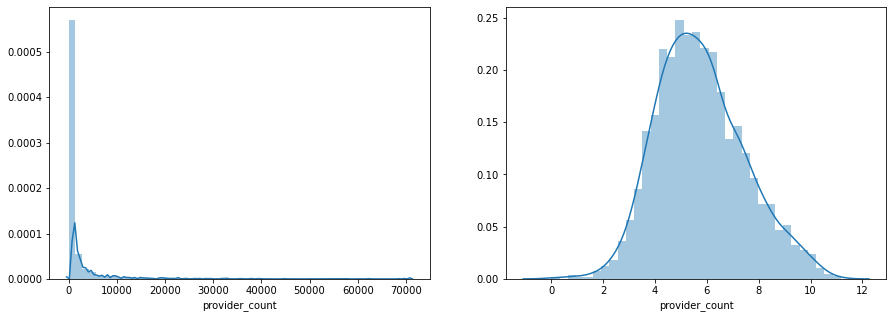

```python
# Distribution of Dependent variable before and after transformation
fig, (ax1, ax2) = plt.subplots(1,2,figsize=(15,5))
sns.distplot(train_y_log, ax=ax2)
sns.distplot(train_y_lasso, ax=ax1);
```

From the plots above, we can see how the distribution of provider count varies before and after log transformation.

#### Run Global Model

In this model, we will build an Ordinary Least Squares (OLS) Regression [[1]](https://en.wikipedia.org/wiki/Ordinary_least_squares) model using predictors selected from feature selection.

```python
X_train_log = sm.add_constant(train_x_log)
global_ols = sm.OLS(train_y_log, X_train_log).fit()
```

```python
global_ols.summary()
```

OLS Regression Results

| Dep. Variable: | provider_count | R-squared: | 0.950 |
| --- | --- | --- | --- |
| Model: | OLS | Adj. R-squared: | 0.950 |
| Method: | Least Squares | F-statistic: | 2904. |
| Date: | Mon, 17 Aug 2020 | Prob (F-statistic): | 0.00 |
| Time: | 16:28:41 | Log-Likelihood: | -1378.2 |
| No. Observations: | 3060 | AIC: | 2798. |
| Df Residuals: | 3039 | BIC: | 2925. |
| Df Model: | 20 |  |  |
| Covariance Type: | nonrobust |  |  |

|  | coef | std err | t | P>\|t\| | [0.025 | 0.975] |
| --- | --- | --- | --- | --- | --- | --- |
| const | -2.8120 | 1.504 | -1.870 | 0.062 | -5.760 | 0.136 |
| minority_pop | 0.1668 | 0.027 | 6.125 | 0.000 | 0.113 | 0.220 |
| grad_deg | 0.2330 | 0.027 | 8.724 | 0.000 | 0.181 | 0.285 |
| total_population | 1.1271 | 0.372 | 3.027 | 0.002 | 0.397 | 1.857 |
| edubase | -0.0523 | 0.350 | -0.149 | 0.881 | -0.739 | 0.634 |
| percap_income | 0.4684 | 0.276 | 1.694 | 0.090 | -0.074 | 1.010 |
| asso_deg | 0.0846 | 0.027 | 3.169 | 0.002 | 0.032 | 0.137 |
| avg_medicare | 3.3141 | 0.636 | 5.215 | 0.000 | 2.068 | 4.560 |
| pop_density | -0.0277 | 0.010 | -2.862 | 0.004 | -0.047 | -0.009 |
| avg_hhsz | -2.7010 | 0.295 | -9.171 | 0.000 | -3.278 | -2.124 |
| white_pop | -0.2686 | 0.048 | -5.567 | 0.000 | -0.363 | -0.174 |
| unemp_rate | 0.0087 | 0.016 | 0.534 | 0.593 | -0.023 | 0.041 |
| median_age | -0.9122 | 0.209 | -4.355 | 0.000 | -1.323 | -0.502 |
| otherace_pop | 0.0319 | 0.016 | 2.004 | 0.045 | 0.001 | 0.063 |
| some_college | 0.0294 | 0.046 | 0.633 | 0.527 | -0.062 | 0.120 |
| avg_presdrug | -3.9498 | 0.666 | -5.934 | 0.000 | -5.255 | -2.645 |
| avg_socsecurity | -0.4264 | 0.250 | -1.706 | 0.088 | -0.917 | 0.064 |
| asian_pop | 0.0608 | 0.012 | 5.168 | 0.000 | 0.038 | 0.084 |
| bach_deg | 0.0059 | 0.039 | 0.152 | 0.879 | -0.071 | 0.082 |
| black_pop | -0.1246 | 0.009 | -13.506 | 0.000 | -0.143 | -0.106 |
| hisp_pop | -0.1045 | 0.024 | -4.303 | 0.000 | -0.152 | -0.057 |

| Omnibus: | 174.445 | Durbin-Watson: | 1.753 |
| --- | --- | --- | --- |
| Prob(Omnibus): | 0.000 | Jarque-Bera (JB): | 673.039 |
| Skew: | 0.116 | Prob(JB): | 7.10e-147 |
| Kurtosis: | 5.286 | Cond. No. | 7.86e+03 |

Warnings:  
[1] Standard Errors assume that the covariance matrix of the errors is correctly specified.  
[2] The condition number is large, 7.86e+03. This might indicate that there are  
strong multicollinearity or other numerical problems.

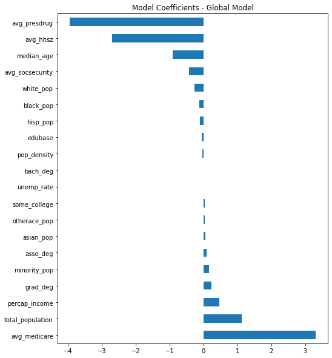

```python
# Plot coefficients picked by model along with their importance
import matplotlib
matplotlib.rcParams['figure.figsize'] = (8.0, 10.0)
global_ols.params[1:].sort_values(ascending=False).plot(kind='barh')
plt.title('Model Coefficients - Global Model');
```

**Regression Equation**

$$ \begin{equation*} provider\_count = 0.1668*minority\_pop + 0.2330*grad\_deg + 1.1271*total\_population - 0.0523*edubase + 0.4684*percap\_income\\ + 0.0846*asso\_deg + 3.3141*avg\_medicare - 0.0277*pop\_density - 2.7010*avg\_hhsz - 0.2686*white\_pop + 0.0087*unemp\_rate\\ - 0.9122*median\_age + 0.0319*otherace\_pop + 0.0294*some\_college - 3.9498*avg\_presdrug - 0.4264*avg\_socsecurity\\ + 0.0608*asian\_pop + 0.0059*bach\_deg - 0.1246*black\_pop - 0.1045*hisp\_pop \end{equation*} $$

```python
# Model Interpretation
coef = 1.1271
((1.01**coef)-1)*100
```

```
1.1278141976397205
```

> **Model Interpretations [[9]](https://www.cscu.cornell.edu/news/statnews/stnews83.pdf):**
> 1. `𝑚𝑖𝑛𝑜𝑟𝑖𝑡𝑦_𝑝𝑜𝑝` - The coefficient is 0.1668. We can say that for 1% increase in minority population, Provider Count will increase by 0.17% ((1.01^coef-1)*100) holding all other predictors fixed.
> 2. `grad_deg` - The coefficient is 0.2330. We can say that for 1% increase in graduate degree holders, Provider Count will increase by 0.23% holding all other predictors fixed.
> 3. `𝑡𝑜𝑡𝑎𝑙_𝑝𝑜𝑝𝑢𝑙𝑎𝑡𝑖𝑜𝑛` - The coefficient is 1.1271. We can say that for 1% increase in total population, Provider Count will increase by 1.127% holding all other predictors fixed.
> 4. `edubase` - The coefficient is -0.0523. We can say that for 1% increase in education base, Provider Count will decrease by 0.05% holding all other predictors fixed.
> 5. `𝑝𝑒𝑟𝑐𝑎𝑝_𝑖𝑛𝑐𝑜𝑚𝑒` - The coefficient is 0.4684. We can say that for 1% increase in per capita income, Provider Count will increase by 0.47% holding all other predictors fixed.
> 6. `𝑎𝑠𝑠𝑜_𝑑𝑒𝑔` - The coefficient is 0.0846. We can say that for 1% increase in associate degree holders, Provider Count will increase by 0.08% holding all other predictors fixed.
> 7. `𝑎𝑣𝑔_𝑚𝑒𝑑𝑖𝑐𝑎𝑟𝑒` - The coefficient is 3.3141. We can say that for 1% increase in average medicare, Provider Count will increase by 3.31% holding all other predictors fixed.
> 8. `pop_density` - The coefficient is -0.0277. We can say that for 1% increase in population density, Provider Count will decrease by 0.027% holding all other predictors fixed.
> 9. `avg_hhsz` - The coefficient is -2.7010. We can say that for 1% increase in average household size, Provider Count will decrease by 2.70% holding all other predictors fixed.
> 10. `white_pop` - The coefficient is -0.2686. We can say that for 1% increase in white population, Provider Count will decrease by 0.27% holding all other predictors fixed.
> 11. `unemp_rate` - The coefficient is 0.0087. We can say that for 1% increase in unemployment rate, Provider Count will increase by 0.009% holding all other predictors fixed.
> 12. `median_age` - The coefficient is -0.9122. We can say that for 1% increase in median age, Provider Count will decrease by 0.91% holding all other predictors fixed.
> 13. `otherace_pop` - The coefficient is 0.0319. We can say that for 1% increase in other race population, Provider Count will increase by 0.03% holding all other predictors fixed.
> 14. `some_college` - The coefficient is 0.0294. We can say that for 1% increase in people with some college education, Provider Count will increase by 0.03% holding all other predictors fixed.
> 15. `𝑎𝑣𝑔_𝑝𝑟𝑒𝑠𝑑𝑟𝑢𝑔` - The coefficient is -3.9498. We can say that for 1% increase in average prescription drug, Provider Count will decrease by 3.95% holding all other predictors fixed.
> 16. `𝑎𝑣𝑔_𝑠𝑜𝑐𝑠𝑒𝑐𝑢𝑟𝑖𝑡𝑦` - The coefficient is -0.4264. We can say that for 1% increase in average social security, Provider Count will decrease by 0.43% holding all other predictors fixed.
> 17. `𝑎sian_𝑝𝑜𝑝` - The coefficient is 0.0608. We can say that for 1% increase in asian population, Provider Count will increase by 0.06% holding all other predictors fixed.
> 18. `bach_deg` - The coefficient is 0.0059. We can say that for 1% increase in bachelors degree holders, Provider Count will increase by 0.005% holding all other predictors fixed.
> 19. `black_pop` - The coefficient is -0.1246. We can say that for 1% increase in black population, Provider Count will decrease by 0.125% holding all other predictors fixed.
> 20. `ℎ𝑖𝑠𝑝_𝑝𝑜𝑝` - The coefficient is -0.1045. We can say that for 1% increase in hispanic population, Provider Count will decrease by 0.105% holding all other predictors fixed.

```python
# Calculate RMSE of global model
pred_val = global_ols.fittedvalues.copy()
new_rmse = rmse(train_y_log, pred_val)
new_rmse
```

```
0.3796336341163295
```

> We can see that the RMSE of our model is 0.38. Since RMSE has the same unit as the dependent variable, we can compare RMSE with the range of dependent variable to see how spread out our residuals are and see how fit our model is. A value of 0.38 on a range of 0-11 (dependent variable range) is pretty small showing the model is a good fit.

#### Verify Assumptions

Here, we will verify regression assumptions [[2]](https://online.stat.psu.edu/stat501/lesson/7/7.3) of global model.

```python
# Residual Value
residual = global_ols.resid
```

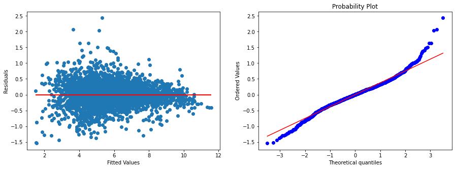

```python
import scipy as sp
fig, (ax1, ax2) = plt.subplots(1,2,figsize=(15,5))

# Residuals vs Fitted
ax1.scatter(pred_val, residual)
ax1.hlines(y=0, xmin=min(pred_val), xmax=max(pred_val), linewidth=2, color='r')
ax1.set_xlabel('Fitted Values')
ax1.set_ylabel('Residuals')

# QQ plot
sp.stats.probplot(residual, plot=ax2, fit=True);
```

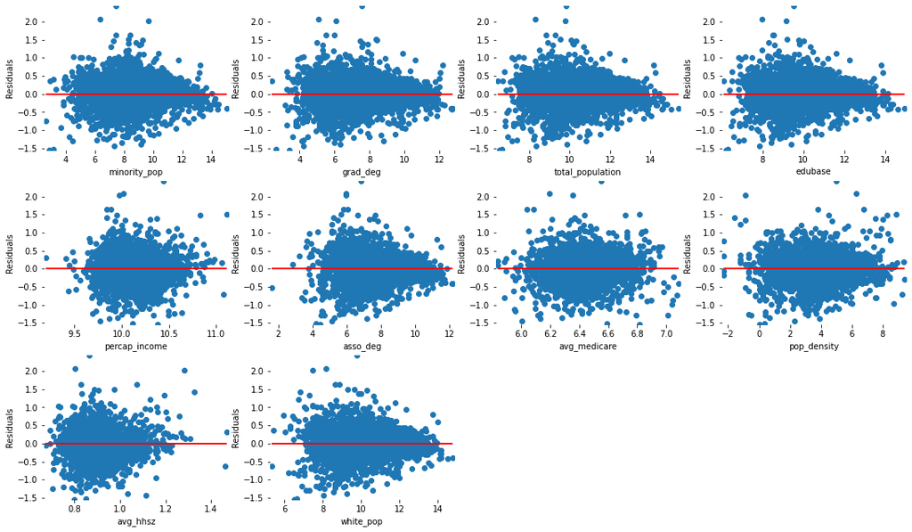

```python
# Residuals vs Predictors
states = train_x_log.columns
fig = plt.figure(figsize=(15, 20))

for sp in range(0,10):
    mini = min(train_x_log.loc[:,states[sp]])
    maxi = max(train_x_log.loc[:,states[sp]])
    ax = fig.add_subplot(7,4,sp+1)
    ax.scatter(train_x_log.loc[:,states[sp]], residual)
    ax.hlines(y=0, xmin=mini, xmax=maxi, linewidth=2, color='r')
    ax.set_xlabel(states[sp])
    ax.set_ylabel('Residuals')
#     ax.set_ylim(0,provType.iloc[0,1])
    plt.xticks(rotation=0)
    for key, spine in ax.spines.items():
        spine.set_visible(False)
    ax.margins(0.01, 0)
plt.tight_layout(pad=0.5) # automatically adjusts layout to fit long labels
plt.show()
```

1. Residuals vs Fitted plot
   - **Constant Variance**: From the plot, we still observe a departure from constant variance as the distance of data points from zero line is not consistent. We can see that the variation in residuals is high initially and then starts to drop.
   - **Independence**: We see that the data is randomly distributed along the zero line indicating the independence holds.
1. Probability Plot
   - **Normality**: From this plot, we see that the residuals follow straight line with departure at the tails. Normality assumption does not hold.
1. Residuals vs Predictors Plot
   - **Linearity**: From the plot, we can see that the residuals for each predictor variable are randomly distributed accross the 0 line. We can say that the linearity assumption holds.

## Spatial Models - Setup

Let's build some spatial models such as [Geographically Weighted Regression](https://pro.arcgis.com/en/pro-app/tool-reference/spatial-statistics/geographicallyweightedregression.htm)(GWR), [Forest Based Classification and Regression Trees](https://pro.arcgis.com/en/pro-app/tool-reference/spatial-statistics/forestbasedclassificationregression.htm) and [Local Bivariate Relationships](https://pro.arcgis.com/en/pro-app/tool-reference/spatial-statistics/localbivariaterelationships.htm) to understand how provider count is influenced by different factors at county level. Before we build these models, let's import libraries, define an output directory and create an environment workspace.

```python
# Import Libraries
import arcpy
import os
```

```python
# Set data directory to output results

arcgis_dir = './arcgis'
home_dir = os.path.join(arcgis_dir, 'home')

print(f"root dir: {arcgis_dir}")
print(f"home dir: {home_dir}")
```

```
root dir: ./arcgis
home dir: ./arcgis\home
```

```python
# Create empty FGDB in data directory
if not arcpy.Exists(os.path.join(home_dir, 'Results.gdb')):
    arcpy.CreateFileGDB_management(home_dir, 'Results.gdb')
```

```python
# Setup Workspace
arcpy.env.workspace = os.path.join(home_dir,'Results.gdb')
arcpy.env.workspace
```

[output not shown]

## Geographically Weighted Regression (GWR) Model

The global model helps us identify a relationship between predictor variables and provider count at the country level. However, the dynamics of how different variables impact provider count can be very different for different counties within a state. The question we ask here is:

`What if an influential variable's impact on provider count varies accross different counties, i.e. how does average household size (or any other variable's) impact provider count vary across different counties?`

To answer this question we will explore `Geographically Weighted Regression Model`.

Learn more about [Geographically Weighted Regression](https://pro.arcgis.com/en/pro-app/tool-reference/spatial-statistics/geographicallyweightedregression.htm).

### Run GWR Model

To run our analysis, we will use the cleaned demographic and health expenditure data layer `demographic_healthexp_clean_allproviders`. The output of the model will be stored in a file geodatabase in `/arcgis/home` which can then be accessed to visualize the results.

```python
# Run GWR and output results to the FGDB
from arcpy.stats import GWR

# Workspace
arcpy.env.workspace

# Url for the layer
lyr_url = allprovider_layer.url

predictors = ['asian_pop','amerind_pop','avg_hhsz','black_pop','hisp_pop',
              'median_age','minority_pop','otherace_pop','percap_income',
              'unemp_rate','white_pop','some_college','grad_deg','avg_healthinsurance',
              'avg_medicare','avg_labtest','avg_presdrug','avg_personalinsurance']

# Define model variables
in_features = lyr_url
dependent_variable = 'provider_count'
model_type = 'CONTINUOUS'
explanatory_variables = predictors
output_features = 'GWRResults_NB1'
neighborhood_type = 'NUMBER_OF_NEIGHBORS'
neighborhood_selection_method = 'USER_DEFINED'
minimum_number_of_neighbors = None
maximum_number_of_neighbors = None
minimum_search_distance = None
maximum_search_distance = None
number_of_neighbors_increment = None
search_distance_increment = None
number_of_increments = None
number_of_neighbors = 50
distance_band = None
prediction_locations = None
explanatory_variables_to_match = None
output_predicted_features = None
robust_prediction = 'ROBUST'
local_weighting_scheme = 'GAUSSIAN'
coefficient_raster_workspace = None

# Run Model
GWR(in_features, dependent_variable, model_type, explanatory_variables, output_features, neighborhood_type,
    neighborhood_selection_method, minimum_number_of_neighbors, maximum_number_of_neighbors, minimum_search_distance,
    maximum_search_distance, number_of_neighbors_increment, search_distance_increment, number_of_increments,
    number_of_neighbors, distance_band, prediction_locations, explanatory_variables_to_match, output_predicted_features,
    robust_prediction, local_weighting_scheme,coefficient_raster_workspace)
```

Output

| id | value |
| --- | --- |
| 0 | ./ArcGIS\home\Results.gdb\GWRResults_NB1 |
| 1 |  |
| 2 |  |

Messages

Start Time: Tuesday, August 18, 2020 10:16:36 AM  
------------- Analysis Details -------------  
Number of Features: 3139  
Dependent Variable: PROVIDER_COUNT  
Explanatory Variables: ASIAN_POP  
AMERIND_POP  
AVG_HHSZ  
BLACK_POP  
HISP_POP  
MEDIAN_AGE  
MINORITY_POP  
OTHERACE_POP  
PERCAP_INCOME  
UNEMP_RATE  
WHITE_POP  
SOME_COLLEGE  
GRAD_DEG  
AVG_HEALTHINSURANCE  
AVG_MEDICARE  
AVG_LABTEST  
AVG_PRESDRUG  
AVG_PERSONALINSURANCE  
Number of Neighbors: 50  
--------------------------------------------  
----------- Model Diagnostics -----------  
R2: 0.9913  
AdjR2: 0.9894  
AICc: 50227.1493  
Sigma-Squared: 466744.4992  
Sigma-Squared MLE: 382271.0780  
Effective Degrees of Freedom: 2570.8903  
-----------------------------------------  
WARNING 110249: Input variables number is 19, will only use the first 10 to create the scatter plot matrix.  
Succeeded at Tuesday, August 18, 2020 10:17:19 AM (Elapsed Time: 43.30 seconds)

### Access GWR Results as Spatially Enabled Dataframe

```python
# Access GWR data from local
gwr_df = pd.DataFrame.spatial.from_featureclass(os.path.join(arcpy.env.workspace,output_features))
gwr_df.head()
```

|  | OBJECTID | SOURCE_ID | provider_count | asian_pop | amerind_pop | avg_hhsz | black_pop | hisp_pop | median_age | minority_pop | otherace_pop | percap_income | unemp_rate | white_pop | some_college | grad_deg | avg_healthinsurance | avg_medicare | avg_labtest | avg_presdrug | avg_personalinsurance | INTRCPT | SE_INTRCPT | C_ASIAN_POP | SE_ASIAN_POP | C_AMERIND_POP | SE_AMERIND_POP | C_AVG_HHSZ | SE_AVG_HHSZ | … |
| --- | --- | --- | --- | --- | --- | --- | --- | --- | --- | --- | --- | --- | --- | --- | --- | --- | --- | --- | --- | --- | --- | --- | --- | --- | --- | --- | --- | --- | --- | --- |
| 0 | 1 | 1 | 1044.0 | 1701 | 423 | 2.85 | 12062 | 3945 | 41.0 | 20664 | 886 | 41430 | 5.6 | 75625 | 16211 | 8931 | 5227.44 | 767.21 | 83.06 | 157.57 | 592.98 | 7083.320304 | 2163.643990 | 0.310213 | 0.034698 | 0.990575 | 0.151966 | -4103.182427 | 1022.086678 | … |
| 1 | 2 | 2 | 5.0 | 6 | 3 | 2.40 | 895 | 8 | 37.9 | 913 | 2 | 16066 | 5.2 | 494 | 199 | 45 | 2149.61 | 475.83 | 36.65 | 102.27 | 191.88 | -1715.168222 | 2993.517884 | -0.458553 | 0.134184 | -0.362877 | 0.178817 | 664.571445 | 1007.225468 | … |
| 2 | 3 | 3 | 621.0 | 421 | 168 | 2.47 | 1422 | 2977 | 40.0 | 5873 | 882 | 24981 | 5.5 | 51908 | 7627 | 2153 | 3081.77 | 547.19 | 51.40 | 114.41 | 313.28 | 3784.309355 | 2761.277425 | -0.214660 | 0.068190 | -0.482683 | 0.178969 | -47.118911 | 993.920916 | … |
| 3 | 4 | 4 | 79.0 | 258 | 69 | 2.77 | 558 | 1307 | 40.4 | 2464 | 759 | 21821 | 3.1 | 16894 | 2043 | 574 | 3042.93 | 557.61 | 47.81 | 122.89 | 289.06 | 1903.340959 | 2856.660109 | 0.182783 | 0.157086 | 0.206154 | 0.184325 | 177.776565 | 1150.078324 | … |
| 4 | 5 | 5 | 1210.0 | 1727 | 307 | 2.81 | 49467 | 9491 | 37.8 | 62154 | 4497 | 26350 | 6.1 | 31300 | 11944 | 5462 | 3356.61 | 520.50 | 54.48 | 109.17 | 344.50 | 863.913879 | 2593.718643 | 0.288447 | 0.170895 | 0.365302 | 0.233586 | 199.681335 | 1023.574012 | … |

```python
gwr_df.shape
```

```
(3139, 67)
```